# Regression (Decision) Trees

The regression tree is actually a decision tree with splits. A regression tree is a form of nonparametric regression that employs multiple step functions. The concept is that by using a sufficient number of sample splits, any functional form can be accurately run. These trees can be particularly useful in regression with categorical variables, where traditional methods such as kernel and series do not apply [1].

[1] indicates that the literature on regression trees has developed a colorful language for describing tools based on the metaphor of a living tree:

i) A split point is node. ii) A subsample is a branch. iii) Increasing the set of nodes is growing a tree. iv) Decreasing the set of nodes is pruning a tree.

In today's study, we focus on obtaining regression trees using Scikit-Learn. Let's start by using a sample data set. We can access this data set from https://nl.mathworks.com/help/stats/select-predictors-for-random-forests.html. Overall, you can download the xlsx version of this data is in https://github.com/halilibrahimgunduz/data.

## Example of carbig

Firstly we load the car dataset. Secondly, we focus on predicting a car's fuel efficiency by a number of potential dependent variables. They are number of cylinders, engine displacement, horsepower, weight, acceleration, model year, and origin country. Finally, we look at the measurment units of these variables.

```python
import pandas as pd
import matplotlib.pyplot as plt

df=pd.read_excel("test.xlsx")
df.info()
```

```
<class 'pandas.core.frame.DataFrame'>
RangeIndex: 406 entries, 0 to 405
Data columns (total 8 columns):
 #   Column        Non-Null Count  Dtype
---  ------        --------------  -----
 0   MPG           398 non-null    float64
 1   Cylinders     406 non-null    int64
 2   Displacement  406 non-null    float64
 3   Horsepower    400 non-null    float64
 4   Weight        406 non-null    int64
 5   Acceleration  406 non-null    float64
 6   Model_Year    406 non-null    int64
 7   Origin        406 non-null    object
dtypes: float64(4), int64(3), object(1)
memory usage: 25.5+ KB
```

This data set contains 8 variables in total of 406 vehicles. While 7 of these variables are quantitative, one of them is qualitative. In addition, we see that some observation of variables are missing (On the one hand, MPG Non-Null Count and Horsepower are 398 and 400. On the other hand, 406 non-null observations are seen except these variables.). We shall remove any rows that have a missing value:

```python
df=df.dropna()
df.info()
```

```
<class 'pandas.core.frame.DataFrame'>
Int64Index: 392 entries, 0 to 405
Data columns (total 8 columns):
 #   Column        Non-Null Count  Dtype
---  ------        --------------  -----
 0   MPG           392 non-null    float64
 1   Cylinders     392 non-null    int64
 2   Displacement  392 non-null    float64
 3   Horsepower    392 non-null    float64
 4   Weight        392 non-null    int64
 5   Acceleration  392 non-null    float64
 6   Model_Year    392 non-null    int64
 7   Origin        392 non-null    object
dtypes: float64(4), int64(3), object(1)
memory usage: 27.6+ KB
```

The measurment of variable origin is qualitative. Using OrdinalEncoder to transform categorical values, transform these observations to numeric values:

```python
from sklearn.preprocessing import OrdinalEncoder

enc=OrdinalEncoder()
df[["Origin"]]=enc.fit_transform(df[["Origin"]])
df.info()
```

```
<class 'pandas.core.frame.DataFrame'>
Int64Index: 392 entries, 0 to 405
Data columns (total 8 columns):
 #   Column        Non-Null Count  Dtype
---  ------        --------------  -----
 0   MPG           392 non-null    float64
 1   Cylinders     392 non-null    int64
 2   Displacement  392 non-null    float64
 3   Horsepower    392 non-null    float64
 4   Weight        392 non-null    int64
 5   Acceleration  392 non-null    float64
 6   Model_Year    392 non-null    int64
 7   Origin        392 non-null    float64
dtypes: float64(5), int64(3)
memory usage: 27.6 KB
```

From the test.xlsx file, you can see this variable has 7 different categories. We can access these categories by enc.categories_. It gives result sorted in alphabetic order and not by order of appearance.

```python
enc.categories_
```

```
[array([0., 1., 2., 3., 4., 5., 6.])]
```

We then determine that X stacks the inputs we use in our regression tree and y is the MPG (fuel efficiency of a car):

```python
y=df[["MPG"]]
X=df[["Cylinders","Displacement","Horsepower","Weight","Acceleration","Model_Year","Origin"]]
```

After saving features and MPG values to X and y, we create the test and train sets by using train_test_split. In my opinion, we should allocate roughly 80% of the data for training and 20% for testing.

```python
from sklearn.model_selection import train_test_split

X_train,X_test,y_train,y_test=train_test_split(X,y,test_size=0.2,random_state=78)
```

It is useful to use random_state so that in your scripts the dataset is always organized in the same way.

### Growing a regression tree with Scikit-Learn

First, we need to import our Decision Tree Regressor. In doing so, we should enter some beneficial information. When using a family of functions, please always consider the structures inside. From here https://scikit-learn.org/stable/modules/generated/sklearn.tree.DecisionTreeRegressor.html you can find detailed info. For instance, I prefer criterion="poisson" because of Poisson technique that employs reduction in Poisson deviance to locate splits. I also determine max_depth=3 as you should select a maximum number N of nodes (see [1] for further details). Finally, random_state=78 may be selected again.

```python
from sklearn.tree import DecisionTreeRegressor
Regression_Trees_model=DecisionTreeRegressor(criterion="poisson",max_depth=3,random_state=78)
Regression_Trees_model.fit(X_train, y_train)
predictions=Regression_Trees_model.predict(X_test)

print(predictions)
print("Length of the predictions array: ", len(predictions))
```

```
[29.0325     28.9375     29.0325     16.70714286 23.08135593 29.0325
 18.95849057 13.7734375  36.1974359  16.70714286 27.25       13.7734375
 13.7734375  23.08135593 23.08135593 23.08135593 13.7734375  16.70714286
 18.95849057 23.08135593 18.95849057 29.0325     18.95849057 36.1974359
 16.70714286 18.95849057 29.0325     29.0325     36.1974359  29.0325
 29.0325     28.9375     13.7734375  36.1974359  36.1974359  23.08135593
 23.08135593 18.95849057 13.7734375  16.70714286 18.95849057 28.9375
 36.1974359  29.0325     36.1974359  18.95849057 29.0325     13.7734375
 23.08135593 29.0325     23.08135593 13.7734375  29.0325     13.7734375
 18.95849057 28.9375     23.08135593 23.08135593 36.1974359  18.95849057
 18.95849057 13.7734375  27.25       28.9375     13.7734375  18.95849057
 23.08135593 23.08135593 28.9375     23.08135593 36.1974359  23.08135593
 23.08135593 16.70714286 13.7734375  18.95849057 18.95849057 29.0325
 18.95849057]
Length of the predictions array:  79
```

Note that the calculated number of observations (79) matches the number of observations reserved for testing (79).

```python
y_test
```

|  | MPG |
| --- | --- |
| 390 | 34.0 |
| 136 | 31.0 |
| 348 | 23.5 |
| 271 | 18.1 |
| 274 | 27.5 |
| ... | ... |
| 9 | 15.0 |
| 54 | 19.0 |
| 207 | 18.0 |
| 326 | 31.3 |
| 234 | 19.0 |

79 rows × 1 columns

With predictions and y_test, model performance can be calculated using the root mean square error (RMSE):

```python
import math
import sklearn.metrics
mse = sklearn.metrics.mean_squared_error(y_test,predictions)
rmse = math.sqrt(mse)
print("The difference between actual and predicted values", rmse)
```

```
The difference between actual and predicted values 4.110725703480176
```

Let's visualize our regression tree (classification trees tend to provide more insights in their graphical representation):

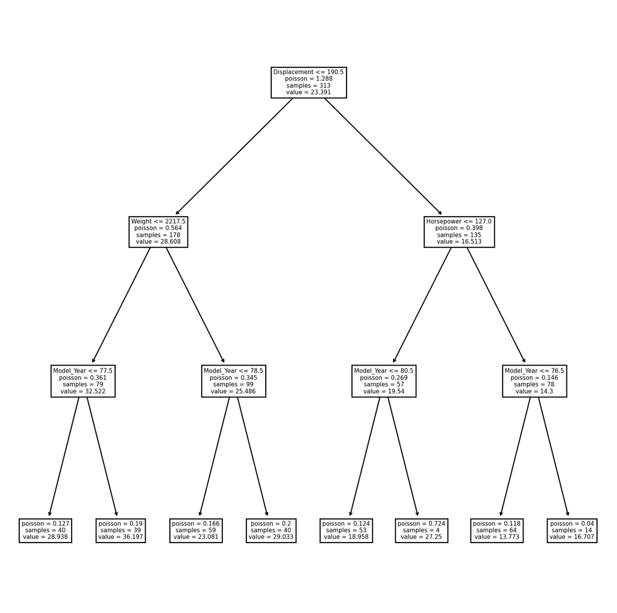

```python
from sklearn.tree import plot_tree
plt.figure(figsize=(10,10), dpi=200)
plot_tree(Regression_Trees_model, feature_names=X.columns);
```

### References

[1] Hansen, B. (2022). Econometrics. Princeton University Press.